# TIL6022 Project Group 7

Group Memebers

- Viresh Budhram: 5426359
- Iris den Ouden: 5879671
- Jelle Top: 5656982
- Ivaylo Iliev: 6294340
- Finn van Benthem: 6239730

# 1. Research Objectives and Research Questions:

Main objective: How have air travel patterns, including passenger volumes and destination preferences, evolved for travelers to and from Dutch airports between the pre-Covid period(2015-2019) and post-Covid(2021-2024)?

Sub objectives :

1. What's the difference between intercontinental and international flights in terms of number of passengers and number of flights?
2. What is the load factor (number of passenger per flight) and how it changed over time?
3. What are the changes in air travel behaviour of passengers per month before covid and after covid in terms of prefered destinations both for short- and long-haul destinations?
4. Which continent region did Dutch people chosed as their favorite for their vacation abroad per year? Has covid affected it?"

# 2. Dataset & Motivation

The dataset provides information on flight movements, passengers, cargo, and mail at Dutch airports. The available data is presented on a yearly basis from 1997 onwards and on a monthly basis from 1999 to 2024. For this assignment, we will focus on the data related to flight movements and passengers at Dutch airport Schiphol. For flight movements, the dataset shows differences between commercial air traffic flights and local flights. The dataset includes all the data for the period before COVID-19 (2015-2019) and after COVID-19 (2021-2024) that we need to process for the assignment.

The dataset we will use for our project is dataset_full.csv This dataset is extracted from: https://opendata.cbs.nl/statline/portal.html?_la=en&_catalog=CBS&tableId=37478eng&_theme=1185

# 3. Data Pipeline [Methodology]

Methodologies that will be used to answer the sub and main research questions

Every datapipeline consists of the three basic components:

1. Data sources: What does the data consists of? Which data do we need?
2. Transformation and processing: transformation can exists out of operations sucg as grouping, filtering, and sorting . In this step, it is important that the data is cleansed and prepared.
3. Visualisation: in this part, the data will be used for analysis and will be made more visual.

## Step 1: Data sources

For this analysis, a dataset will be used which consists of the following information: - Airport ID number, periods - Flights (total, arrivals, departures) - Passengers (total, arrivals, departures, scheduled, non-scheduled) - Destinations (total, Europe, EU, intercontinental, every part of every continent) - Cargo (total, destinations) - Mail (total, destinations)

Not all information from this dataset will be relevant, the following data will be needed:

- Airport ID number, periods, flight information about passengers.

## Step 2: Data Transformation and processing

To make sure the data will be used correctly, it is important to filter, group and sort the data. The following steps will be/are followed (???):

1. Filter out all unnecccessary data:

   1.1 Data about mail and cargo flights.

   1.2 Remove data about local flights. Local flights are not common in the Netherlands as and are not relevant for this project. The local flights that did happen where not meant to transport people from one airport to the other as public transport is way faster for that.
2. Filter data about periods. This projects focusses on the years 2016-2019 and 2021-2024, the useful data during these periods of time will be extracted from the datasheet.
3. Replace Airport ID number with logical name. An ID number does not give direct information about which airport is being analyzed. By replacing the ID number with a logical name, this will be more clear when multiple aiports will be analyzed. For example: AO3590 = Schiphol.
4. Split the data column 'periods'. This column is formulated as year-month (2001MM01 = january 2001 | 2001KW01 = Quarter 1 2001 | 2001JJ00 = Year 2001), this column is splitted in years and months/quarters/year which creates an extra column. This is done to remove the letters from this data column and to be able to analyze the data by year and to compare the data in time by month and/or quarters.
5. The outcome is an overview of the data related to passenger flights going abroad during the periods 2016-2019 and 2021-2024.

## Step 3: Visualisation

The final step of the data pipeline focuses on visualizing the processed data to uncover trends and insights related to air travel patterns. To answer the main objective—how air travel patterns, a combination of visualizations will be used.

For comparing intercontinental and international flights in terms of passenger numbers and flight volumes, a grouped bar chart will display the data, allowing for a clear comparison across these categories and time periods. The load factor (passengers per flight) will be shown using a line chart, highlighting trends over time for different periods before and after COVID-19.

Additional visualizations like heatmaps for seasonal travel patterns or choropleth maps for geographic distribution of passengers by country will complement the main graphs. These visualizations will use Python’s `matplotlib`, `seaborn`, and `Plotly` to provide clear, well-labeled insights and make trends in air travel behavior easy to interpret across the periods in focus.

## Results:

### Code Data Preprosessing

```python
#Library Imports
import pandas as pd
import plotly.express as px
import plotly.graph_objects as go
import matplotlib.pyplot as plt
from plotly.subplots import make_subplots
```

```python
#Preprocessing

# Define the file path
file_path = 'C:/Users/MSI/Desktop/downloaded files from uni/Year 4/Q1/TIL6022 TIL Python Programming/New folder/dataset_full.csv'

# Read the CSV file
df_raw = pd.read_csv(file_path, delimiter=";")

def preprocessing(df):

    #Filter data, so that we work only with Passengers and only for years above 2015(excluding) 2020
    df = df.iloc[:, :43]
    df = df[ (df['Periods'].str[:4].astype(int) >= 2015)]

    # Function to extract year, month, and quarter from the Periods column
    def extract_date(period):
        #the function returns year, Month, Quarter and since we
        #have eiither Month or Quarter, the missing one is set as None

        year = period[:4]               # Extract the year
        if 'MM' in period:
            month = str(period[6:])     # Extract month number for MM format
            return year, month, None
        elif 'KW' in period:
            quarter = str(period[6:])   # Extract quarter number for KW format
            return year, None, quarter
        return year, None, None

    # Create new columns for Year, Month, and Quarter
    df[['Year', 'Month_Num', 'Quarter_Num']] = df['Periods'].apply(extract_date).apply(pd.Series)

    # Map months to month names
    month_names = {
        '01': 'January', '02': 'February', '03': 'March', '04': 'April',
        '05': 'May', '06': 'June', '07': 'July', '08': 'August',
        '09': 'September', '10': 'October', '11': 'November', '12': 'December'
    }

    # Map quarters to quarter names
    quarter_names = {
        '01': 'Q1', '02': 'Q2', '03': 'Q3', '04': 'Q4'
    }

    #Map airports to their airport quarter
    airport_names = {
        'A043590':'Amsterdam Schiphol', 'A043596':'Rotterdam','A043591':'Eindhoven'
    }

    # Further data processing
    df['Month'] = df['Month_Num'].map(month_names)
    df['Quarter'] = df['Quarter_Num'].map(quarter_names)
    df['Airport'] = df['Airports'].map(airport_names)

    # fill in the missing data in the column "month" with the Quarter or year
    df['Month'] = df['Month'].fillna(df['Quarter'])
    df['Month'] = df['Month'].fillna(df['Year'])

    df = df.drop('Quarter', axis=1)         #Quarter is no longer needed
    # Drop the Month_Num and Quarter_Num columns as they are not needed anymore
    df.drop(columns=['Month_Num', 'Quarter_Num'], inplace=True)
    df.drop(columns=['Airports'], inplace=True)

    #Local flights are not revelant for this project
    df.drop(columns=['LocalFlights_2'], inplace=True)

    # List of columns to move and the column after which to insert them
    cols_to_move = ['Month', 'Year', 'Airport']
    insert_after = 'Periods'

    # Get the current columns and find the index of 'Period'
    cols = list(df.columns)
    insert_at = cols.index(insert_after) + 1

    # Remove the columns to move from their original positions
    for col in cols_to_move:
        cols.remove(col)

    # Insert the columns after 'Period'
    for i, col in enumerate(cols_to_move):
        cols.insert(insert_at + i, col)

    # Reorder the DataFrame
    df = df[cols]

    return df

df_processesd = preprocessing(df_raw)
df_processesd.head(15)
```

### Subquestion 1: Comparison of European and Intercontinental passenger numbers

To gain insights into answers to the dynamics of the by Covid-19 impacted Dutch air travel patterns, a comparison must be made between passenger number in the pre and post covid years. Additionally, a split has been executed to examine to passenger number differences between intercontinental travellers and travellers who fly to and from destinations within the European continent. Both decisions result in better understanding of changes of air travel patterns, and how covid affected this in terms of passenger volumes.

#### 1.1 Approach and Assumptions

To ensure that the yearly passenger numbers in intercontinental flights can be compared to the European passenger numbers some filtering in the data must be executed. Additionally, airports such as Eindhoven airport and Rotterdam the Hague airport are excluded since these airports only operate European flights and not intercontinental flights. Thus, data from these airports is not applicable to this comparison.

Furthermore, it is decided to focus on only the yearly data instead of monthly or quarterly data. By merely including the yearly passenger numbers during the years of 2016 – 2023 it would ensure that the visualizations yield a clear overview of passenger numbers so that trends in these numbers could easily be extracted. Lastly, it is decided to also include the years that are identified as ‘special cases’ (2020 and 2021) in the analysis. These years are involved to create a comprehensive visualization so that the pre-and post-covid years can easily be compared in terms of passenger decline or growth.

#### 1.2 Results

Hence, two visualization graphs are constructed. Firstly, the histogram displaying the yearly total travel numbers, and travel volumes for European and intercontinental travellers. Also see Figure (1).

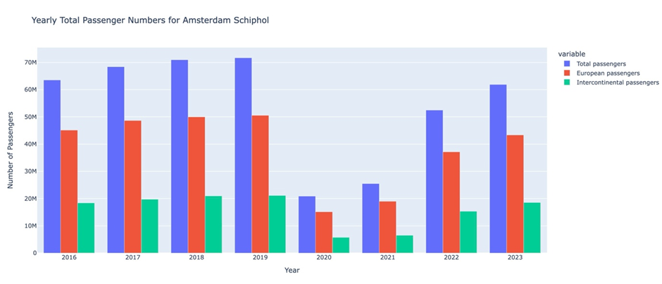

*Figure 1 Histogram of yearly passenger numbers.*

Secondly, a line graph (Figure (2)) has been created to underline the shown passengers volumes in the histogram. In addition, the line graph allows for a better comparison between European and intercontinental passenger volumes since the yearly total passenger volumes are excluded. Moreover, the data is visualized in such a way that year-on-year trends are clearly spotted.

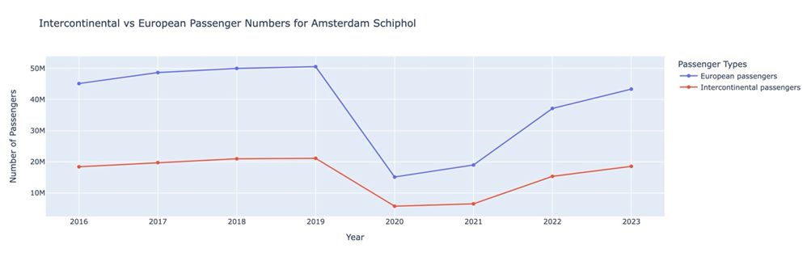

*Figure 2 Line graph of European versus Intercontinental yearly passenger volumes.*

#### 1.4 Code subquestion 1

```python
def difference_passenger_numbers(df):
    airports = ["Amsterdam Schiphol"]  # Filter on only Amsterdam Schiphol
    df_filtered = df.loc[
        (df["Airport"].isin(airports)) &
        (df["Periods"].str.contains(r"\d{4}JJ00")) &
        (df["Year"].astype(int).isin([2016, 2017, 2018, 2019, 2020, 2021, 2022, 2023, 2024]))
    ].copy()  # Filter rows

    # Convert relevant columns to numeric, filling NaNs
    df_filtered["TotalCountryOfOriginDestination_21"] = pd.to_numeric(df_filtered["TotalCountryOfOriginDestination_21"], errors="coerce").fillna(0)
    df_filtered["EuropeTotal_22"] = pd.to_numeric(df_filtered["EuropeTotal_22"], errors="coerce").fillna(0)
    df_filtered["TotalIntercontinentalPassengers_25"] = pd.to_numeric(df_filtered["TotalIntercontinentalPassengers_25"], errors="coerce").fillna(0)

    # Group data by Year and sum relevant columns
    df_grouped = df_filtered.groupby("Year")[
        ["TotalCountryOfOriginDestination_21", "EuropeTotal_22", "TotalIntercontinentalPassengers_25"]
    ].sum().reset_index()

    # Rename columns to reflect the legend changes
    df_grouped = df_grouped.rename(columns={
        "TotalCountryOfOriginDestination_21": "Total passengers",
        "EuropeTotal_22": "European passengers",
        "TotalIntercontinentalPassengers_25": "Intercontinental passengers"
    })

    # Create a grouped bar chart to show all three categories separately
    fig = px.bar(df_grouped,
                 x="Year",
                 y=["Total passengers", "European passengers", "Intercontinental passengers"],
                 color_discrete_sequence=["#636EFA", "#EF553B", "#00CC96"],
                 labels={"value": "Number of Passengers", "Year": "Year"},
                 title="Yearly Total Passenger Numbers for Amsterdam Schiphol",
                 barmode="group",  # Group the bars
                 height=600)

    # Customize hover data to show totals and individual segments
    fig.update_traces(hovertemplate='%{x}: %{y}')
    fig.update_layout(barmode='group')

    fig.show()

# Assuming df_processed is already loaded
difference_passenger_numbers(df_processesd)
```

```python
# VISUALIZE PASSENGER NUMBER TRENDS INTERNATIONAL VS INTERCONTINENTAL PRE/POST COVID

def create_line_graph(df):
    airports = ["Amsterdam Schiphol"]  # Filter on only Amsterdam Schiphol
    df_filtered = df.loc[
        (df["Airport"].isin(airports)) &
        (df["Periods"].str.contains(r"\d{4}JJ00")) &
        (df["Year"].astype(int).isin([2016, 2017, 2018, 2019, 2020, 2021, 2022, 2023, 2024]))
    ].copy()  # Filter rows

    # Convert columns to numeric, filling NaNs
    df_filtered["EuropeTotal_22"] = pd.to_numeric(df_filtered["EuropeTotal_22"], errors="coerce").fillna(0)
    df_filtered["TotalIntercontinentalPassengers_25"] = pd.to_numeric(df_filtered["TotalIntercontinentalPassengers_25"], errors="coerce").fillna(0)

    # Group data by Year and Airport, then sum values
    df_grouped = df_filtered.groupby(["Year"])[
        ["EuropeTotal_22", "TotalIntercontinentalPassengers_25"]
    ].sum().reset_index()

    # Rename columns for better legend labels
    df_grouped = df_grouped.rename(columns={
        "EuropeTotal_22": "European passengers",
        "TotalIntercontinentalPassengers_25": "Intercontinental passengers"
    })

    # Create a line graph comparing European and Intercontinental passengers
    fig = px.line(df_grouped,
                  x="Year",
                  y=["European passengers", "Intercontinental passengers"],
                  labels={"value": "Number of Passengers", "Year": "Year"},
                  title="Intercontinental vs European Passenger Numbers for Amsterdam Schiphol",
                  markers=True)  # Add markers for each point

    # Customize layout and trace appearance
    fig.update_traces(mode='lines+markers')
    fig.update_layout(legend_title_text='Passenger Types')

    fig.show()

# Assuming df_processed is already loaded
create_line_graph(df_processesd)
```

### Subquestion 2: What is the load factor (number of passengers per flight) and how did it change over time?

To answer this research question, the total number of flights and passengers per airport, per year, will be analyzed. This analysis will include overall flight and passenger data, as well as this data separated by arrivals and departures. Based on this information, the load factor will be calculated for each airport per year and represented visually in graphs. The following abbreviation are used:

- AMS = Amsterdam Schiphol Airport
- EIN = Eindhoven Airport
- RTM = Rotterdam The Hague Airport

Similarly to the original problem, the timeline is divided between 3 periods:

- Pre-covid = year 2016 – 2019
- Post covid = year 2022 and 2023
- Covid = 2020 and 2021

#### 2.1 Approach and Assumptions

To gain more insight in the load factor, this analysis focuses on the three largest airports in the Netherlands: Amsterdam Schiphol Airport, Eindhoven Airport, and Rotterdam The Hague Airport. For each airport, the data on the number of passengers and flights, including arrivals and departures, will be examined.

This research will concentrate on full-year data, specifically from 2016 to 2023. This decision excludes 2024, which is based on the fact that the available data for this year only covers January to August. As a result, this data will not provide a complete overview of the load factor for 2024 and would therefore not be comparable to the load factors of previous years.

#### 2.2 Results

A total of eighteen graphs are created to provide a comprehensive understanding of the load factor. In Figure 3, the total number of flights and passengers (arrivals + departures) for the three airports are presented per year. This graph illustrates the significant decline in both flights and passengers during the Covid period, with a gradual recovery during the post-Covid years at all airports.

Colour Legend:

- Amsterdam Schiphol Flights.
- Eindhoven Flights.
- Rotherdam Flights.
- Amsterdam Schiphol Passengers .
- Eindhoven Passengers.
- Rotherdam Passengers.

[figure not shown]

Using the data from these graphs, the load factor for each airport, which is the ratio of the total passengers to total flights, can be derived. The resulting load factor graphs reflect a similar trend, as shown in Figure 4.

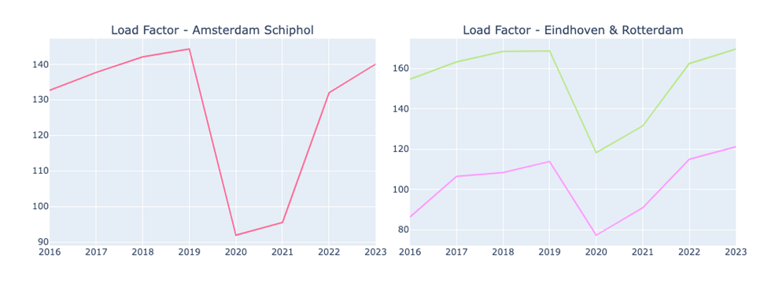

*Figure 4: Load Factor per Airport.*

This same analysis is also conducted with a focus on arrivals and departures separately to determine if there is a noticeable difference between these two. By examining the data for arrivals and departures separately, it can be identified if trends in passenger numbers and therefore load factors differ between these categories. The results are presented in Figure 5 and Figure 6.

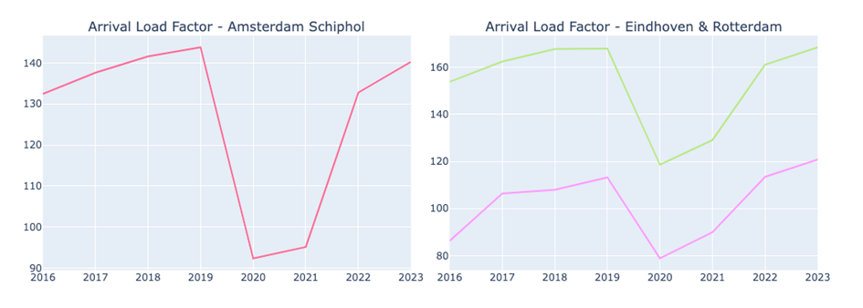

*Figure 5: Arrival Load Factor per Airport.*

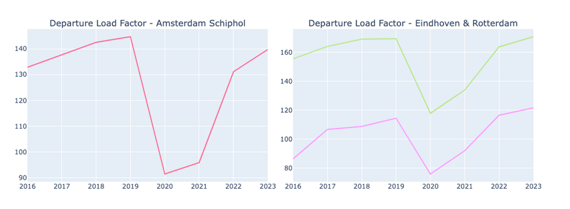

*Figure 6: Departure Load Factor per Airport.*

As shown in Figure 5 and Figure 6, the load factor follows the same trend for every airport as it reaches a peak in 2019 during the pre-Covid period, drops to a low in 2020, and then gradually improves in the post-Covid years. It should be noticed that both EIN and RTM achieve a new, higher load factor in the post-Covid years in comparison to the pre-Covid years.

Over the years, the load factor for arrivals and departures remains relatively similar. In Figure 7, a table is provided displaying the load factor values for both arrivals and departures at the three airports. As can be seen in the table, the load factor does not vary significantly between arrivals and departures, which indicated that the number of passengers arriving at the airport is nearly the same as the number departing even during Covid.

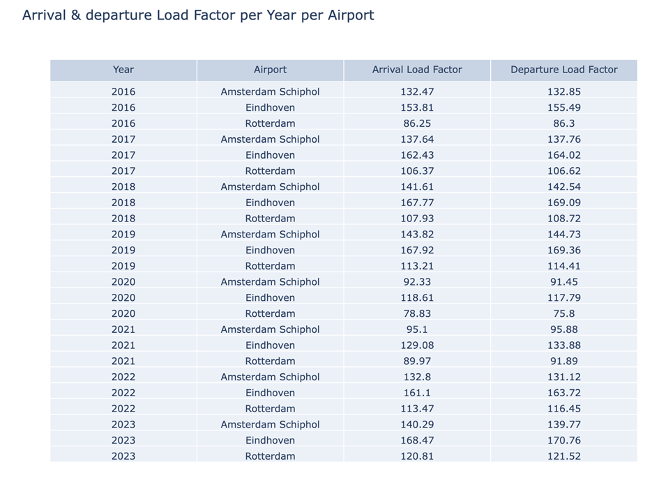

*Figure 7: Arrival&Departure Load Factor per Year per Airport.*

#### 2.3 Conclusion

By examining all visualizations, it can be concluded that the total load factor did change during the Covid period. For both Eindhoven Airport and Rotterdam The Hague Airport, the load factor reaches a higher level than the all-time high observed during the pre-Covid period. Amsterdam Schiphol Airport is nearly back to its pre-Covid levels and is expected to continue increasing in the upcoming years, potentially also surpassing the all-time high seen before the pandemic.

#### 2.4 Code Subquestion 2

```python
# TOTAL

# total flights
    # AMS
def total_flights_ams(df):
    airports = ["Amsterdam Schiphol"]
    df_filtered = df.loc[
        (df["Airport"].isin(airports)) &
        (df["Periods"].str.contains(r"\d{4}JJ00")) &
        (df["Year"].astype(int).isin([2016, 2017, 2018, 2019, 2020, 2021, 2022, 2023]))].copy()

    df_filtered["totalflights"] = pd.to_numeric(df_filtered["TotalFlights_3"], errors = "coerce").fillna(0)
    df_grouped = df_filtered.groupby(["Year", "Airport"])["totalflights"].sum().reset_index()

    return df_grouped

    # EIN & RTM
def total_flights_airports(df):
    airports = ["Eindhoven", "Rotterdam"]
    df_filtered = df.loc[
        (df["Airport"].isin(airports)) &
        (df["Periods"].str.contains(r"\d{4}JJ00")) &
        (df["Year"].astype(int).isin([2016, 2017, 2018, 2019, 2020, 2021, 2022, 2023]))].copy()

    df_filtered["totalflights"] = pd.to_numeric(df_filtered["TotalFlights_3"], errors = "coerce").fillna(0)
    df_grouped = df_filtered.groupby(["Year", "Airport"])["totalflights"].sum().reset_index()

    return df_grouped

# total passengers
    #AMS
def total_passengers_ams(df):
    airports = ["Amsterdam Schiphol"]
    df_filtered = df.loc[
        (df["Airport"].isin(airports)) &
        (df["Periods"].str.contains(r"\d{4}JJ00")) &
        (df["Year"].astype(int).isin([2016, 2017, 2018, 2019, 2020, 2021, 2022, 2023]))].copy()

    df_filtered["totalpassengers"] = pd.to_numeric(df_filtered["TotalPassengers_12"], errors = "coerce").fillna(0)
    df_grouped = df_filtered.groupby(["Year", "Airport"])["totalpassengers"].sum().reset_index()

    return df_grouped

    # EIN & RTM
def total_passengers_airports(df):
    airports = ["Eindhoven", "Rotterdam"]
    df_filtered = df.loc[
        (df["Airport"].isin(airports)) &
        (df["Periods"].str.contains(r"\d{4}JJ00")) &
        (df["Year"].astype(int).isin([2016, 2017, 2018, 2019, 2020, 2021, 2022, 2023]))].copy()

    df_filtered["totalpassengers"] = pd.to_numeric(df_filtered["TotalPassengers_12"], errors = "coerce").fillna(0)
    df_grouped = df_filtered.groupby(["Year", "Airport"])["totalpassengers"].sum().reset_index()

    return df_grouped

# Function to calculate load factor
def calculate_load_factor(df_flights, df_passengers, flight_col, passenger_col, load_factor_col):
    df_load_factor = pd.merge(df_flights, df_passengers, on=["Year", "Airport"], how="outer")
    df_load_factor[load_factor_col] = (df_load_factor[passenger_col] / df_load_factor[flight_col]).round(2)
    return df_load_factor

# retrieve data
df_flights_ams = total_flights_ams(df_processesd)
df_flights_airports = total_flights_airports(df_processesd)
df_passengers_ams = total_passengers_ams(df_processesd)
df_passengers_airports = total_passengers_airports(df_processesd)

# calculate load factor
    # AMS
df_flights_ams_total = total_flights_ams(df_processesd)
df_passengers_ams_total = total_passengers_ams(df_processesd)
df_load_factor_ams_total = calculate_load_factor(df_flights_ams_total, df_passengers_ams_total, "totalflights", "totalpassengers", "total_load_factor")

    # EIN & RTM
df_flights_airports_total = total_flights_airports(df_processesd)
df_passengers_airports_total = total_passengers_airports(df_processesd)
df_load_factor_airports_total = calculate_load_factor(df_flights_airports_total, df_passengers_airports_total,"totalflights", "totalpassengers", "total_load_factor")

# Create subplots
fig_subplots = make_subplots(
    rows=3, cols=2,
    subplot_titles=(
        "Total Flights - Amsterdam Schiphol", "Total Flights - Eindhoven & Rotterdam",
        "Total Passengers - Amsterdam Schiphol", "Total Passengers - Eindhoven & Rotterdam",
        "Total Load Factor - Amsterdam Schiphol", "Total Load Factor - Eindhoven & Rotterdam"
    ),vertical_spacing=0.1, horizontal_spacing=0.05)

def add_traces_to_fig_total():
    # add lines to suplots
        # AMS flights
    for airport in df_flights_ams["Airport"].unique():
        df_filtered = df_flights_ams[df_flights_ams["Airport"] == airport]
        fig_subplots.add_trace(
            go.Scatter(x=df_filtered["Year"], y=df_filtered["totalflights"], mode='lines', name=f'{airport} Flights'),row=1, col=1)

        #  EIN & RTM flights
    for airport in df_flights_airports["Airport"].unique():
        df_filtered = df_flights_airports[df_flights_airports["Airport"] == airport]
        fig_subplots.add_trace(
            go.Scatter(x=df_filtered["Year"], y=df_filtered["totalflights"], mode='lines', name=f'{airport} Flights'),row=1, col=2)

        # AMS passengers
    for airport in df_passengers_ams["Airport"].unique():
        df_filtered = df_passengers_ams[df_passengers_ams["Airport"] == airport]
        fig_subplots.add_trace(
            go.Scatter(x=df_filtered["Year"], y=df_filtered["totalpassengers"], mode='lines', name=f'{airport} Passengers'),row=2, col=1)

        #  EIN & RTM passengers
    for airport in df_passengers_airports["Airport"].unique():
        df_filtered = df_passengers_airports[df_passengers_airports["Airport"] == airport]
        fig_subplots.add_trace(
            go.Scatter(x=df_filtered["Year"], y=df_filtered["totalpassengers"], mode='lines', name=f'{airport} Passengers'),row=2, col=2)


    # load factor AMS
    for airport in df_load_factor_ams_total["Airport"].unique():
        df_filtered = df_load_factor_ams_total[df_load_factor_ams_total["Airport"] == airport]
        fig_subplots.add_trace(
            go.Scatter(x=df_filtered["Year"], y=df_filtered["total_load_factor"], mode='lines', name=f'{airport} Load Factor'),row=3, col=1)

        # load factor EIN & RTM
    for airport in df_load_factor_airports_total["Airport"].unique():
        df_filtered = df_load_factor_airports_total[df_load_factor_airports_total["Airport"] == airport]
        fig_subplots.add_trace(
            go.Scatter(x=df_filtered["Year"], y=df_filtered["total_load_factor"], mode='lines', name=f'{airport} Load Factor'),row=3,col=2)

add_traces_to_fig_total()
# layouy subplots
fig_subplots.update_layout(
    height=1500, width=1100,
    title_text="Total Flights, Passengers, and Load Factor (2016 - 2023)",
    legend=dict(orientation="h",yanchor="bottom",y=-0.09,xanchor="center",x=0.5),)


fig_subplots.show()
```

```python
# ARRIVAL

# arrival flights
    # AMS
def total_arrival_flights_ams(df):
    airports = ["Amsterdam Schiphol"]
    df_filtered = df.loc[
        (df["Airport"].isin(airports)) &
        (df["Periods"].str.contains(r"\d{4}JJ00")) &
        (df["Year"].astype(int).isin([2016, 2017, 2018, 2019, 2020, 2021, 2022, 2023]))].copy()

    df_filtered["totalarrivalflights"] = pd.to_numeric(df_filtered["TotalArrivalsFlights_6"], errors = "coerce").fillna(0)
    df_grouped = df_filtered.groupby(["Year", "Airport"])["totalarrivalflights"].sum().reset_index()

    return df_grouped

    # EIN & RTM
def total_arrival_flights_airports(df):
    airports = ["Eindhoven", "Rotterdam"]
    df_filtered = df.loc[
        (df["Airport"].isin(airports)) &
        (df["Periods"].str.contains(r"\d{4}JJ00")) &
        (df["Year"].astype(int).isin([2016, 2017, 2018, 2019, 2020, 2021, 2022, 2023]))].copy()

    df_filtered["totalarrivalflights"] = pd.to_numeric(df_filtered["TotalArrivalsFlights_6"], errors = "coerce").fillna(0)
    df_grouped = df_filtered.groupby(["Year", "Airport"])["totalarrivalflights"].sum().reset_index()

    return df_grouped

# total passengers
    # AMS
def total_arrival_passengers_ams(df):
    airports = ["Amsterdam Schiphol"]
    df_filtered = df.loc[
        (df["Airport"].isin(airports)) &
        (df["Periods"].str.contains(r"\d{4}JJ00")) &
        (df["Year"].astype(int).isin([2016, 2017, 2018, 2019, 2020, 2021, 2022, 2023]))].copy()

    df_filtered["totalarrivalpassengers"] = pd.to_numeric(df_filtered["TotalArrivalsPassengers_15"], errors = "coerce").fillna(0)
    df_grouped = df_filtered.groupby(["Year", "Airport"])["totalarrivalpassengers"].sum().reset_index()

    return df_grouped

    # EIN & RTM
def total_arrival_passengers_airports(df):
    airports = ["Eindhoven", "Rotterdam"]
    df_filtered = df.loc[
        (df["Airport"].isin(airports)) &
        (df["Periods"].str.contains(r"\d{4}JJ00")) &
        (df["Year"].astype(int).isin([2016, 2017, 2018, 2019, 2020, 2021, 2022, 2023]))].copy()

    df_filtered["totalarrivalpassengers"] = pd.to_numeric(df_filtered["TotalArrivalsPassengers_15"], errors = "coerce").fillna(0)
    df_grouped = df_filtered.groupby(["Year", "Airport"])["totalarrivalpassengers"].sum().reset_index()

    return df_grouped

# Retrieve  data
df_flights_ams = total_arrival_flights_ams(df_processesd)
df_flights_airports = total_arrival_flights_airports(df_processesd)
df_passengers_ams = total_arrival_passengers_ams(df_processesd)
df_passengers_airports = total_arrival_passengers_airports(df_processesd)

# calculate load factor
    # AMS
df_loadfactor_ams_arrival = pd.merge(df_flights_ams, df_passengers_ams, on=["Year", "Airport"])
df_loadfactor_ams_arrival["load_factor"] = (df_loadfactor_ams_arrival["totalarrivalpassengers"] / df_loadfactor_ams_arrival["totalarrivalflights"]).round(2)

    # EIN & RTM
df_loadfactor_airports_arrival = pd.merge(df_flights_airports, df_passengers_airports, on=["Year", "Airport"])
df_loadfactor_airports_arrival["load_factor"] = (df_loadfactor_airports_arrival["totalarrivalpassengers"] / df_loadfactor_airports_arrival["totalarrivalflights"]).round(2)


# Create subplots
fig_subplots = make_subplots(
    rows=3, cols=2,
    subplot_titles=(
        "Arrival flights - Amsterdam Schiphol", "Arrival flights - Eindhoven & Rotterdam",
        "Arrival Passengers - Amsterdam Schiphol", "Arrival Passengers - Eindhoven & Rotterdam",
        "Arrival Load Factor - Amsterdam Schiphol", "Arrival Load Factor - Eindhoven & Rotterdam"
    ),vertical_spacing=0.1, horizontal_spacing=0.05)

def add_traces_to_fig_arrivals():
    # add line to subplots
        # flights AMS
    for airport in df_flights_ams["Airport"].unique():
        df_filtered = df_flights_ams[df_flights_ams["Airport"] == airport]
        fig_subplots.add_trace(
            go.Scatter(x=df_filtered["Year"], y=df_filtered["totalarrivalflights"], mode='lines', name=f'{airport} Flights'),row=1, col=1)

        # flights EIN & RTM
    for airport in df_flights_airports["Airport"].unique():
        df_filtered = df_flights_airports[df_flights_airports["Airport"] == airport]
        fig_subplots.add_trace(
            go.Scatter(x=df_filtered["Year"], y=df_filtered["totalarrivalflights"], mode='lines', name=f'{airport} Flights'),row=1, col=2)

        # passengers AMS
    for airport in df_passengers_ams["Airport"].unique():
        df_filtered = df_passengers_ams[df_passengers_ams["Airport"] == airport]
        fig_subplots.add_trace(
            go.Scatter(x=df_filtered["Year"], y=df_filtered["totalarrivalpassengers"], mode='lines', name=f'{airport} Passengers'),row=2, col=1)

        # passengers EIN & RTM
    for airport in df_passengers_airports["Airport"].unique():
        df_filtered = df_passengers_airports[df_passengers_airports["Airport"] == airport]
        fig_subplots.add_trace(
            go.Scatter(x=df_filtered["Year"], y=df_filtered["totalarrivalpassengers"], mode='lines', name=f'{airport} Passengers'),row=2, col=2)

        # load factor AMS
    for airport in df_loadfactor_ams_arrival["Airport"].unique():
        df_filtered = df_loadfactor_ams_arrival[df_loadfactor_ams_arrival["Airport"] == airport]
        fig_subplots.add_trace(
            go.Scatter(x=df_filtered["Year"], y=df_filtered["load_factor"], mode='lines', name=f'{airport} Load Factor'),row=3, col=1)

        #  load factor EIN & RTM
    for airport in df_loadfactor_airports_arrival["Airport"].unique():
        df_filtered = df_loadfactor_airports_arrival[df_loadfactor_airports_arrival["Airport"] == airport]
        fig_subplots.add_trace(
            go.Scatter(x=df_filtered["Year"], y=df_filtered["load_factor"], mode='lines', name=f'{airport} Load Factor'),row=3, col=2)

add_traces_to_fig_arrivals()
# layout subplots
fig_subplots.update_layout(
    height=1500, width=1100,
    title_text="Total Arrival Flights, Passengers, and Load Factor (2016 - 2023)",
    legend=dict( orientation="h", yanchor="top", y=-0.03, xanchor="center", x=0.5),)


fig_subplots.show()
```

```python
# DEPARTURE

# total departure flights
    # AMS
def total_departure_flights_ams(df):
    airports = ["Amsterdam Schiphol"]
    df_filtered = df.loc[
        (df["Airport"].isin(airports)) &
        (df["Periods"].str.contains(r"\d{4}JJ00")) &
        (df["Year"].astype(int).isin([2016, 2017, 2018, 2019, 2020, 2021, 2022, 2023]))].copy()

    df_filtered["totaldepartureflights"] = pd.to_numeric(df_filtered["TotalDeparturesFlights_9"], errors = "coerce").fillna(0)
    df_grouped = df_filtered.groupby(["Year", "Airport"])["totaldepartureflights"].sum().reset_index()

    return df_grouped

    # EIN & RTM
def total_departure_flights_airports(df):
    airports = ["Eindhoven", "Rotterdam"]
    df_filtered = df.loc[
        (df["Airport"].isin(airports)) &
        (df["Periods"].str.contains(r"\d{4}JJ00")) &
        (df["Year"].astype(int).isin([2016, 2017, 2018, 2019, 2020, 2021, 2022, 2023]))].copy()

    df_filtered["totaldepartureflights"] = pd.to_numeric(df_filtered["TotalDeparturesFlights_9"], errors = "coerce").fillna(0)
    df_grouped = df_filtered.groupby(["Year", "Airport"])["totaldepartureflights"].sum().reset_index()

    return df_grouped

# total passengers
    # AMS
def total_departure_passengers_ams(df):
    airports = ["Amsterdam Schiphol"]
    df_filtered = df.loc[
        (df["Airport"].isin(airports)) &
        (df["Periods"].str.contains(r"\d{4}JJ00")) &
        (df["Year"].astype(int).isin([2016, 2017, 2018, 2019, 2020, 2021, 2022, 2023]))].copy()

    df_filtered["totaldeparturepassengers"] = pd.to_numeric(df_filtered["TotalDeparturesPassengers_18"], errors = "coerce").fillna(0)
    df_grouped = df_filtered.groupby(["Year", "Airport"])["totaldeparturepassengers"].sum().reset_index()

    return df_grouped

    # EIN & RTM
def total_departure_passengers_airports(df):
    airports = ["Eindhoven", "Rotterdam"]
    df_filtered = df.loc[
        (df["Airport"].isin(airports)) &
        (df["Periods"].str.contains(r"\d{4}JJ00")) &
        (df["Year"].astype(int).isin([2016, 2017, 2018, 2019, 2020, 2021, 2022, 2023]))].copy()

    df_filtered["totaldeparturepassengers"] = pd.to_numeric(df_filtered["TotalDeparturesPassengers_18"], errors = "coerce").fillna(0)
    df_grouped = df_filtered.groupby(["Year", "Airport"])["totaldeparturepassengers"].sum().reset_index()

    return df_grouped

# retrieve data
df_flights_ams = total_departure_flights_ams(df_processesd)
df_flights_airports = total_departure_flights_airports(df_processesd)
df_passengers_ams = total_departure_passengers_ams(df_processesd)
df_passengers_airports = total_departure_passengers_airports(df_processesd)

# Load factor
    # AMS
df_loadfactor_ams_dep = pd.merge(df_flights_ams, df_passengers_ams, on=["Year", "Airport"])
df_loadfactor_ams_dep["load_factor"] = (df_loadfactor_ams_dep["totaldeparturepassengers"] / df_loadfactor_ams_dep["totaldepartureflights"]).round(2)

    # RTM & EIN
df_loadfactor_airports_dep = pd.merge(df_flights_airports, df_passengers_airports, on=["Year", "Airport"])
df_loadfactor_airports_dep["load_factor"] = (df_loadfactor_airports_dep["totaldeparturepassengers"] / df_loadfactor_airports_dep["totaldepartureflights"]).round(2)

# Create subplots
fig_subplots = make_subplots(
    rows=3, cols=2,
    subplot_titles=(
        "Departure flights - Amsterdam Schiphol", "Departure flights - Eindhoven & Rotterdam",
        "Departure Passengers - Amsterdam Schiphol", "Departure Passengers - Eindhoven & Rotterdam",
        "Departure Load Factor - Amsterdam Schiphol", "Departure Load Factor - Eindhoven & Rotterdam"
    ),vertical_spacing=0.1, horizontal_spacing=0.05)

def add_traces_to_fig_departure():
    # add line plots into subplots
        # flights AMS
    for airport in df_flights_ams["Airport"].unique():
        df_filtered = df_flights_ams[df_flights_ams["Airport"] == airport]
        fig_subplots.add_trace(
            go.Scatter(x=df_filtered["Year"], y=df_filtered["totaldepartureflights"], mode='lines', name=f'{airport} Flights'),row=1, col=1)

        # flights EIN & RTM
    for airport in df_flights_airports["Airport"].unique():
        df_filtered = df_flights_airports[df_flights_airports["Airport"] == airport]
        fig_subplots.add_trace(
            go.Scatter(x=df_filtered["Year"], y=df_filtered["totaldepartureflights"], mode='lines', name=f'{airport} Flights'),row=1, col=2)

        # passengers AMS
    for airport in df_passengers_ams["Airport"].unique():
        df_filtered = df_passengers_ams[df_passengers_ams["Airport"] == airport]
        fig_subplots.add_trace(
            go.Scatter(x=df_filtered["Year"], y=df_filtered["totaldeparturepassengers"], mode='lines', name=f'{airport} Passengers'),row=2, col=1)

        # passengers EIN & RTM
    for airport in df_passengers_airports["Airport"].unique():
        df_filtered = df_passengers_airports[df_passengers_airports["Airport"] == airport]
        fig_subplots.add_trace(
            go.Scatter(x=df_filtered["Year"], y=df_filtered["totaldeparturepassengers"], mode='lines', name=f'{airport} Passengers'),row=2, col=2)

        # load factor AMS
    for airport in df_loadfactor_ams_dep["Airport"].unique():
        df_filtered = df_loadfactor_ams_dep[df_loadfactor_ams_dep["Airport"] == airport]
        fig_subplots.add_trace(
            go.Scatter(x=df_filtered["Year"], y=df_filtered["load_factor"], mode='lines', name=f'{airport} Load Factor'),row=3, col=1)

        # load factor EIN & RTM
    for airport in df_loadfactor_airports_dep["Airport"].unique():
        df_filtered = df_loadfactor_airports_dep[df_loadfactor_airports_dep["Airport"] == airport]
        fig_subplots.add_trace(
            go.Scatter(x=df_filtered["Year"], y=df_filtered["load_factor"], mode='lines', name=f'{airport} Load Factor'),row=3, col=2)

add_traces_to_fig_departure()
# update layout
fig_subplots.update_layout(
    height=1500, width=1100,
    title_text="Total Departure Flights, Passengers, and Load Factor (2016 - 2023)",
    legend=dict(orientation="h",yanchor="bottom",y=-0.09,xanchor="center",x=0.5),)

# Show the plot
fig_subplots.show()
```

```python
# TABLE LOAD FACTOR

# Arrival load factor
    # AMS
df_flights_ams_arrival = total_arrival_flights_ams(df_processesd)
df_passengers_ams_arrival = total_arrival_passengers_ams(df_processesd)
df_load_factor_ams_arrival = calculate_load_factor(df_flights_ams_arrival, df_passengers_ams_arrival, "totalarrivalflights", "totalarrivalpassengers", "arrival_load_factor")

    # EIN & RTM
df_flights_airports_arrival = total_arrival_flights_airports(df_processesd)
df_passengers_airports_arrival = total_arrival_passengers_airports(df_processesd)
df_load_factor_airports_arrival = calculate_load_factor(df_flights_airports_arrival, df_passengers_airports_arrival, "totalarrivalflights", "totalarrivalpassengers", "arrival_load_factor")

# Departure load factor
    # AMS
df_flights_ams_departure = total_departure_flights_ams(df_processesd)
df_passengers_ams_departure = total_departure_passengers_ams(df_processesd)
df_load_factor_ams_departure = calculate_load_factor(df_flights_ams_departure, df_passengers_ams_departure, "totaldepartureflights", "totaldeparturepassengers", "departure_load_factor")

    # EIN & RTM
df_flights_airports_departure = total_departure_flights_airports(df_processesd)
df_passengers_airports_departure = total_departure_passengers_airports(df_processesd)
df_load_factor_airports_departure = calculate_load_factor(df_flights_airports_departure, df_passengers_airports_departure, "totaldepartureflights", "totaldeparturepassengers", "departure_load_factor")

# AMS
df_ams = pd.merge(df_load_factor_ams_arrival[['Year', 'Airport', 'arrival_load_factor']],
                  df_load_factor_ams_departure[['Year', 'Airport', 'departure_load_factor']], on=["Year", "Airport"], how="outer")

# EIN & RTM
df_airports = pd.merge(df_load_factor_airports_arrival[['Year', 'Airport', 'arrival_load_factor']],
                       df_load_factor_airports_departure[['Year', 'Airport', 'departure_load_factor']], on=["Year", "Airport"], how="outer")


table_data = pd.concat([df_ams, df_airports], ignore_index=True)
table_data = table_data.sort_values(by=['Year', 'Airport'])

# table layout
table_trace = go.Table(
    header=dict(values=["Year", "Airport", "Arrival Load Factor", "Departure Load Factor"]),
    cells=dict(values=[
        table_data['Year'],
        table_data['Airport'],
        table_data['arrival_load_factor'].astype(str),
        table_data['departure_load_factor'].astype(str)]))

fig_table = go.Figure(table_trace)
fig_table.update_layout(height=800, width=900, title_text="Arrival & departure Load Factor per Year per Airport")

fig_table.show()
```

### Subquestion 3: How has air travel behaviour among passengers changed on a monthly basis before and after COVID-19 for both short-haul and long-haul destinations?

To address this sub-question, we analysed a dataset containing flight and passenger numbers. This analysis focused on the three major airports in the Netherlands: Schiphol Airport, Eindhoven Airport, and Rotterdam The Hague Airport. The goal was to compare passenger travel behaviour before and after COVID-19 across short- and long-haul destinations.

#### 3.1 Approach

To examine travel behaviour for short- and long-haul destinations, we differentiated between these two categories. For the purpose of this analysis, all destinations within Europe were classified as short-haul, while all destinations outside Europe were designated as long-haul. Another essential aspect of the analysis involved comparing travel behaviour before and after COVID-19. The dataset included all relevant years for this analysis, with the pre-COVID period defined as 2016 to 2019 and the post-COVID period from 2021 to August 2024. The results have been plotted on a monthly basis for the periods before and after COVID-19.

#### 3.2 Results

These findings highlight the significant impact of COVID-19 on Dutch air travel, with long-haul flights showing a slightly slower return to pre-pandemic levels compared to short-haul travel.

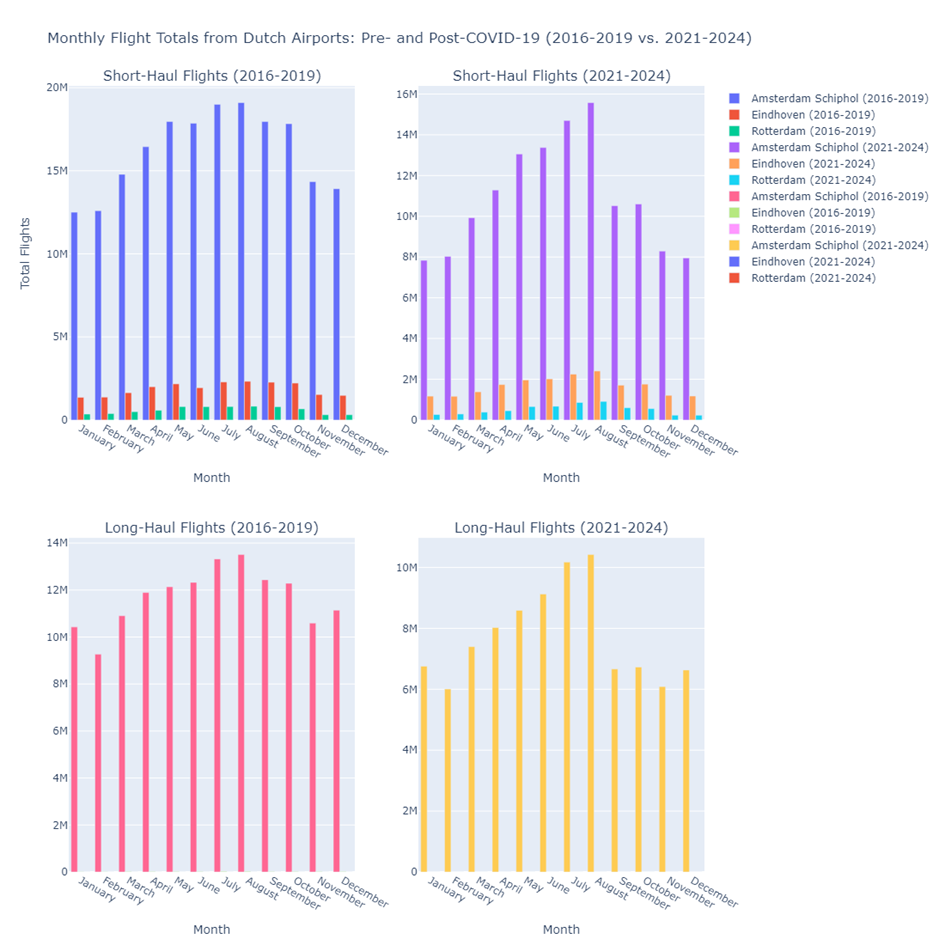

*Figure 8: Monthly Flight Totals from dutch airports: Pre and Post-Covid-19 (2016-2019 vs 2021-2024).*

#### 3.4 Code Subquestion 3

```python
def total_flights_short_long_haul_combined(df):
    airports = ["Amsterdam Schiphol", "Eindhoven", "Rotterdam"]
    short_haul = ['EUCountries_23', 'OtherEurope_24']
    long_haul = [
        'SouthAfrica_31', 'America_32', 'NorthAmerica_33', 'CentralAmerica_34',
        'SouthAmerica_35', 'Asia_36', 'WestAsia_37', 'SouthEastAsia_38',
        'NorthEastAsia_39', 'Oceania_40'
    ]

    # Convert Year to integer to avoid type issues
    df["Year"] = pd.to_numeric(df["Year"], errors="coerce")

    df_filtered = df.loc[
        (df["Airport"].isin(airports)) &
        (df["Month"].isin([
            "January", "February", "March", "April", "May", "June",
            "July", "August", "September", "October", "November", "December"
        ])) &
        (df["Year"].isin([2016, 2017, 2018, 2019, 2021, 2022, 2023, 2024]))
    ].copy()

    df_filtered["Scheduled_10"] = pd.to_numeric(df_filtered["Scheduled_10"], errors="coerce").fillna(0)
    df_filtered["NonScheduled_11"] = pd.to_numeric(df_filtered["NonScheduled_11"], errors="coerce").fillna(0)

    # Calculate total flights
    df_filtered["totalflights"] = df_filtered["Scheduled_10"] + df_filtered["NonScheduled_11"]

    # Categorize the years
    df_filtered["Period"] = df_filtered["Year"].apply(
        lambda x: "2016-2019" if x <= 2019 else "2021-2024"
    )

    # Create columns for short-haul and long-haul flights
    df_filtered["short_haul"] = df_filtered[short_haul].sum(axis=1)
    df_filtered["long_haul"] = df_filtered[long_haul].sum(axis=1)

    # Group by Period, Month, and Airport
    df_grouped = df_filtered.groupby(
        ["Period", "Month", "Airport"]
    )[["short_haul", "long_haul"]].sum().reset_index()

    # Explicitly define the month order
    month_order = [
        "January", "February", "March", "April", "May", "June",
        "July", "August", "September", "October", "November", "December"
    ]

    # Ensure months are ordered correctly
    df_grouped["Month"] = pd.Categorical(df_grouped["Month"], categories=month_order, ordered=True)

    # Create 2x2 subplots for each period and haul type
    fig = make_subplots(
        rows=2, cols=2,
        subplot_titles=[
            "Short-Haul Flights (2016-2019)", "Short-Haul Flights (2021-2024)",
            "Long-Haul Flights (2016-2019)", "Long-Haul Flights (2021-2024)"
        ],
        vertical_spacing=0.15, horizontal_spacing=0.1
    )

    # Define row and column mappings for each subplot
    subplot_positions = {
        ("short_haul", "2016-2019"): (1, 1),
        ("short_haul", "2021-2024"): (1, 2),
        ("long_haul", "2016-2019"): (2, 1),
        ("long_haul", "2021-2024"): (2, 2),
    }

    # Add traces for each combination of period and haul type
    for haul_type, period in subplot_positions:
        row, col = subplot_positions[(haul_type, period)]
        df_period = df_grouped[df_grouped["Period"] == period]
        for airport in airports:
            df_airport = df_period[df_period["Airport"] == airport]
            fig.add_trace(
                go.Bar(
                    x=df_airport["Month"],
                    y=df_airport[haul_type],
                    name=f"{airport} ({period})",
                    showlegend=True
                ),
                row=row, col=col
            )

    # Update layout for better readability
    fig.update_layout(
        height=1100,
        width=1100,
        title="Monthly Flight Totals from Dutch Airports: Pre- and Post-COVID-19 (2016-2019 vs. 2021-2024)",
        yaxis_title="Total Flights"
    )

    # Set x-axes to display all months in each subplot
    fig.update_xaxes(
        title_text="Month",
        tickmode="array",
        tickvals=month_order,
        ticktext=month_order,
        categoryorder='array',
        categoryarray=month_order
    )

    fig.show()

# Run the function
total_flights_short_long_haul_combined(df_processesd)
```

### Sub-question 4: Which continent region did Dutch people choose as their favorite for vacation abroad per year, and has COVID-19 affected this choice?

#### 4.2 Results

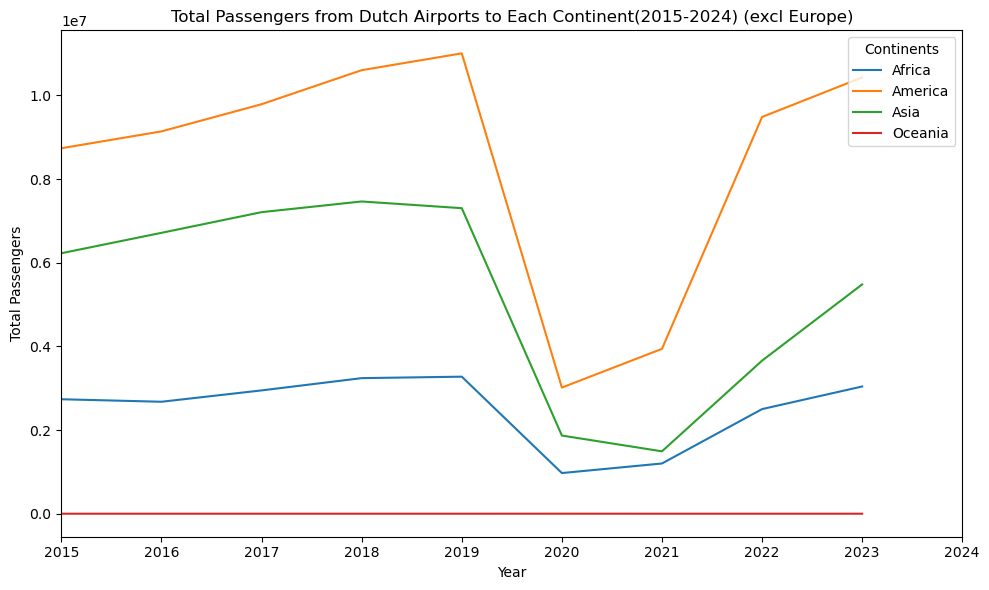

*Figure 9: Total passenger volume from Dutch airports to each continent from 2015 to 2024.*

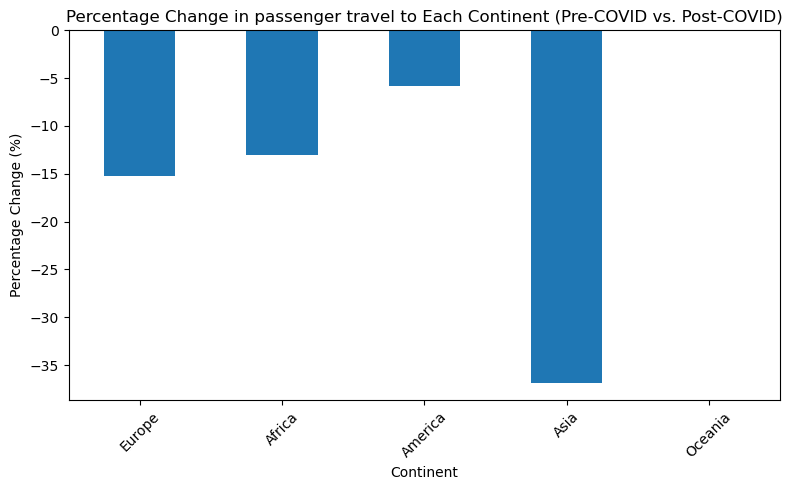

| Continent | Pre-COVID Avg Flights | Post-COVID Avg Flights | Percentage Change |
| --- | --- | --- | --- |
| Europe | 3,183,847 | 2,698,906 | -15.23 |
| Africa | 175,033 | 152,283 | -12.99 |
| America | 579,718 | 545,696 | -5.87 |
| Asia | 410,829 | 259,491 | -36.84 |
| Oceania | 0 | 0 | NaN |

*Table 1: Comparison of Pre-COVID and Post-COVID Average Passenger Volume to Each Continent*

#### 4.3 Conclusion

The table reveals that Europe was consistently the most popular continent for Dutch travelers across all periods. However, COVID-19 had a significant impact on travel volumes to all continents, with Asia seeing the steepest drop due to stricter travel restrictions. Post-COVID, average travel to America rebounded faster, Europe and Africa are still more than 10% behing Pre-covid lelevs, and Asia's showing the worth results with recovery that lagged substantially. This suggests that COVID-19 altered travel patterns, with preferences shifting slightly due to accessibility and restriction levels in various regions.

#### 4.4 Code Subquestion 4

```python
# Step 1: Load and Process the Data
data_file_path = file_path
data = pd.read_csv(data_file_path, delimiter=';')
columns_of_interest = ['Periods', 'EuropeTotal_22', 'Africa_26', 'America_32', 'Asia_36', 'Oceania_40']
data_subset = data[columns_of_interest].copy()  # Use .copy() to avoid modifying the original DataFrame
data_subset['Year'] = data_subset['Periods'].str.extract(r'(\d{4})').astype(int)

# Filter for pre-COVID (2015-2019) and post-COVID (2021-2024) years
annual_data = data_subset[data_subset['Periods'].str.contains('JJ')]
annual_passenger_counts = annual_data.groupby('Year').sum().reset_index()
filtered_data = annual_passenger_counts[annual_passenger_counts['Year'].isin(range(2015, 2025))]

# Step 2: Generate Figure 1 (Total Flights by Continent)
plt.figure(figsize=(10, 6))
for col in ['Africa_26', 'America_32', 'Asia_36', 'Oceania_40']:
    continent_name = col.split('_')[0]
    plt.plot(filtered_data['Year'], filtered_data[col], label=continent_name)

plt.title("Total Passengers from Dutch Airports to Each Continent (2015-2024)")
plt.xlabel("Year")
plt.ylabel("Total Passengers")
plt.legend(title="Continents", loc="upper right")
plt.xticks(ticks=range(2015, 2025), labels=range(2015, 2025))
plt.xlim(2015, 2024)
plt.tight_layout()
plt.savefig('pre_post_covid_flights_per_continent_filtered_corrected.png')
plt.show()

# Step 3: Filter data for pre-COVID (2015-2019) and post-COVID (2022-2024) years
pre_covid_data = data_subset[data_subset['Year'].isin([2015, 2016, 2017, 2018, 2019])]
post_covid_data = data_subset[data_subset['Year'].isin([2022, 2023, 2024])]

# Step 4: Calculate the mean passenger counts for both periods
pre_covid_totals = pre_covid_data[['EuropeTotal_22', 'Africa_26', 'America_32', 'Asia_36', 'Oceania_40']].mean()
post_covid_totals = post_covid_data[['EuropeTotal_22', 'Africa_26', 'America_32', 'Asia_36', 'Oceania_40']].mean()

# Step 5: Calculate the percentage change
percentage_change = ((post_covid_totals - pre_covid_totals) / pre_covid_totals) * 100

# Step 6: Plot the percentage change
plt.figure(figsize=(8, 5))
percentage_change_simple = percentage_change[['EuropeTotal_22', 'Africa_26', 'America_32', 'Asia_36', 'Oceania_40']]
percentage_change_simple.index = ['Europe', 'Africa', 'America', 'Asia', 'Oceania']
percentage_change_simple.plot(kind='bar', legend=False, rot=45)
plt.title("Percentage Change in passenger travel to Each Continent (Pre-COVID vs. Post-COVID)")
plt.xlabel("Continent")
plt.ylabel("Percentage Change (%)")
plt.tight_layout()
plt.show()

# Step 7: Create Table for Comparison of Pre-COVID and Post-COVID Average Flights
comparison_table = pd.DataFrame({
    'Continent': ['Europe', 'Africa', 'America', 'Asia', 'Oceania'],
    'Pre-COVID Avg Flights': pre_covid_totals,
    'Post-COVID Avg Flights': post_covid_totals,
    'Percentage Change': percentage_change
})

# Step 8: Format the table for prettier output
comparison_table['Pre-COVID Avg Flights'] = comparison_table['Pre-COVID Avg Flights'].apply(lambda x: f"{x:,.0f}")
comparison_table['Post-COVID Avg Flights'] = comparison_table['Post-COVID Avg Flights'].apply(lambda x: f"{x:,.0f}")
comparison_table['Percentage Change'] = comparison_table['Percentage Change'].apply(lambda x: f"{x:,.2f}")

# Step 9: Set a more readable table format
comparison_table.set_index('Continent', inplace=True)

# Step 10: Print the formatted table
print(comparison_table)
```

### Main question asnwer: How have air travel patterns, including passenger volumes and destination preferences, evolved for travelers to and from Dutch airports between the pre-Covid period(2015-2019) and post-Covid(2021-2024)?

Air travel patterns to and from Dutch airports have experienced significant changes between the pre-COVID period (2015-2019) and the post-COVID period (2021-2024).